# Coursera Reproducible Research - Project 1

Olivier Gagneux

3/4/2018

#### Loading libraries

```r
#install.packages("dplyr")
library(dplyr)

#install.packages("ggplot2")
library(ggplot2)
```

#### Loading and preprocessing the data

```r
dat <- read.csv("data/activity.csv")
```

#### What is mean total number of steps taken per day?

##### Calculate the total number of steps taken per day

Note: Missing values should not count as “zero steps”

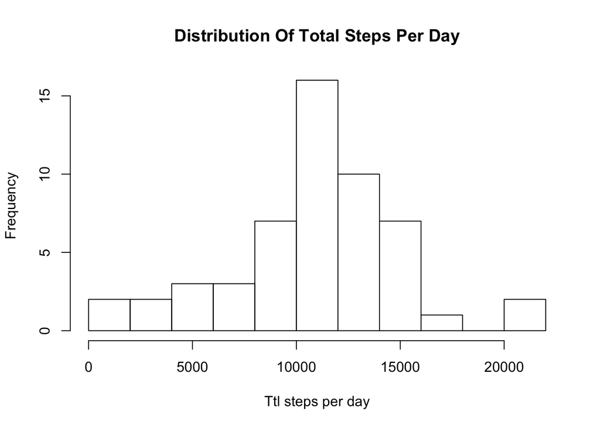

```r
hist((dat %>%
        group_by(date) %>%
        summarise(ttl = sum(steps))
        )$ttl
     ,breaks = 10
     ,main = "Distribution Of Total Steps Per Day"
     ,xlab ="Ttl steps per day")
```

##### Calculate and report the mean and median of the total number of steps taken per day

```r
day_stats <- dat %>%
   group_by(date) %>%
   summarise(ttl = sum(steps)
            )  %>%
   summarise(mean = mean(ttl, na.rm = TRUE)
            ,median = median(ttl, na.rm = TRUE)
)
```

The mean is 10766.2, the median is 10765.

#### What is the average daily activity pattern?

Make a time series plot (i.e. 𝚝𝚢𝚙𝚎 = “𝚕”) of the 5-minute interval (x-axis) and the average number of steps taken, averaged across all days (y-axis)

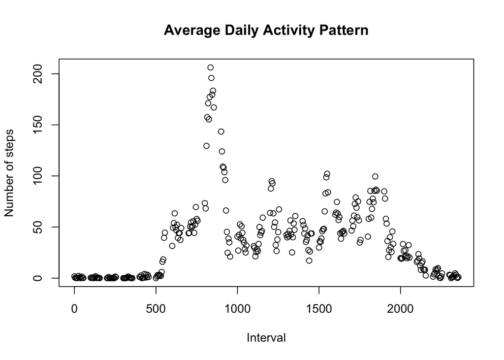

```r
intervals <- dat %>%
   group_by(interval) %>%
   summarise(mean = mean(steps, na.rm = TRUE)
            )

 plot(intervals$interval, intervals$mean
     ,main = "Average Daily Activity Pattern"
     ,xlab = "Interval"
     ,ylab = "Number of steps"
     )
```

##### Which 5-minute interval, on average across all the days in the dataset, contains the maximum number of steps?

```r
max_steps_interval <-  intervals %>%
   filter(mean == max(mean))  %>%
   select(interval)
```

The interval with the highest average step count across all dates is interval 835.

#### Imputing missing values

Note that there are a number of days/intervals where there are missing values (coded as 𝙽𝙰). The presence of missing days may introduce bias into some calculations or summaries of the data.

##### Calculate and report the total number of missing values in the dataset (i.e. the total number of rows with 𝙽𝙰s)

```r
rows_with_na <- nrow(dat %>% filter(is.na(steps)))
```

There are 2304 rows with NAs.

##### Devise a strategy for filling in all of the missing values in the dataset.

Is date or interval a better predictor for the number of steps?  
(Do steps vary more across dates or across intervals?)

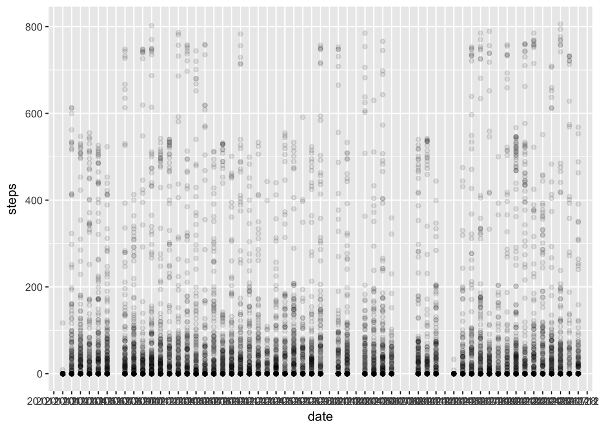

```r
ggplot(dat , aes(x = date, y = steps)) +
   geom_point(alpha = 0.1) +
   geom_smooth(method = "gam")
```

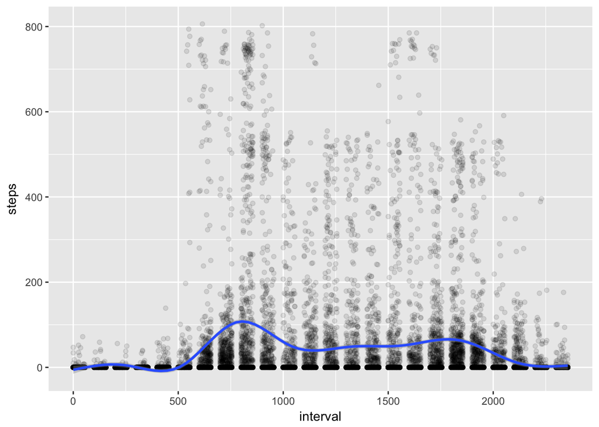

```r
ggplot(dat, aes(x = interval, y = steps)) +
   geom_point(alpha = 0.1) +
   geom_smooth()
```

Interval is a better predictor for steps than date.  
The strategy will be to replace missing values with a random value from the same interval. Many values are zero; Therefore, using mean would yield unrealistic values.

##### Create a new dataset that is equal to the original dataset but with the missing data filled in.

```r
## Returns a random real steps value for a given interval
intervals_random <- dat %>%
   filter(!is.na(steps)) %>%
   select(interval,random_steps = steps) %>%
   group_by(interval) %>%
   sample_n(1)

dat2 <- merge(dat, intervals_random, by="interval") %>%
   mutate(steps = case_when(is.na(steps) ~ random_steps
                                   ,TRUE ~ steps)
             ) %>%
   select(steps, date, interval) %>%
   arrange(date, interval)
```

##### Make a histogram of the total number of steps taken each day

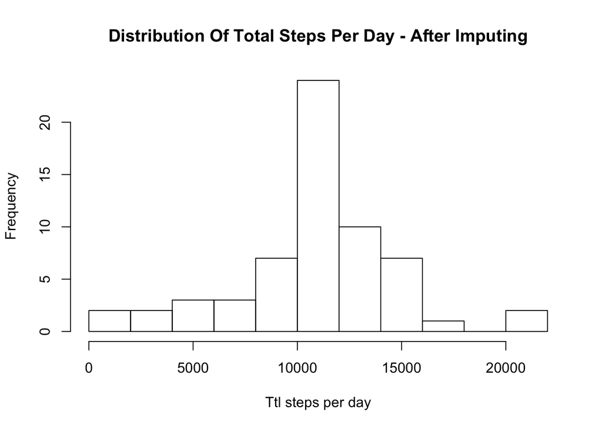

```r
dates2 <- dat2 %>% group_by(date) %>%
   summarize(ttl = sum(steps))

hist(dates2$ttl
     ,breaks = 10
     ,main = "Distribution Of Total Steps Per Day - After Imputing"
     ,xlab ="Ttl steps per day")
```

##### Calculate and report the mean and median total number of steps taken per day.

```r
day_stats2 <- dat2 %>%
   group_by(date) %>%
   summarise(ttl = sum(steps)
            )  %>%
   summarise(mean = mean(ttl, na.rm = TRUE)
            ,median = median(ttl, na.rm = TRUE)
)
```

The mean after imputing is 10831.3, the median is 11263.

##### Do these values differ from the estimates from the first part of the assignment? What is the impact of imputing missing data on the estimates of the total daily number of steps?

The distribution of the values as well as the mean and the median are affected. (Note that each time this is run the results will differ, because the code uses random.)

#### Are there differences in activity patterns between weekdays and weekends?

For this part the 𝚠𝚎𝚎𝚔𝚍𝚊𝚢𝚜() function may be of some help here. Use the dataset with the filled-in missing values for this part.

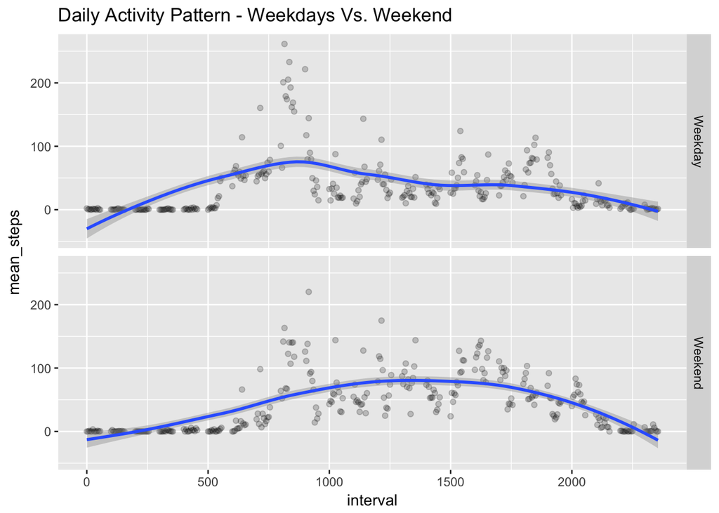

```r
dat3 <- dat2 %>%
   mutate(weekend = case_when(weekdays(as.Date(date), abbrev = TRUE) %in% c("Sat", "Sun") ~ "Weekend"
                              ,TRUE ~ "Weekday"
                              )
   )

weekends <- dat3 %>%
   group_by(weekend, interval)  %>%
   summarise(mean_steps = mean(steps, na.rm = TRUE))

ggplot(weekends, aes(x = interval, y = mean_steps)) +
   ggtitle("Daily Activity Pattern - Weekdays Vs. Weekend") +
   geom_point(alpha = 0.2) +
   geom_smooth() +
   facet_grid(weekend~.)
```